# TP3 - Exercice 2 : Composition du lait et rendement fromager

Tracy ANDRE

**QUESTION 1 - IMPORTATION DES DONNEES**

```r
setwd("C:/Users/andre/OneDrive/Documents/S6/Stats/TP3_Donnees")
lait <- read.table("Lait.txt",header=T, sep=" ")
attach(lait)
head(lait)
```

|  | Densite | TxButy | TxProt | TxCase | ExSec | Rendement |
| --- | --- | --- | --- | --- | --- | --- |
| 1 | 1.0318 | 37.7 | 35.7 | 28.5 | 127.1 | 15.35 |
| 2 | 1.0316 | 37.5 | 35.3 | 28.0 | 128.7 | 14.72 |
| 3 | 1.0314 | 37.0 | 32.8 | 25.3 | 124.1 | 14.61 |
| 4 | 1.0311 | 39.5 | 33.7 | 26.8 | 127.5 | 14.56 |
| 5 | 1.0309 | 36.0 | 32.8 | 25.9 | 121.6 | 13.74 |
| 6 | 1.0322 | 36.0 | 33.8 | 26.9 | 124.5 | 14.31 |

```r
summary(lait)
```

```
    Densite          TxButy          TxProt          TxCase
 Min.   :1.026   Min.   :30.50   Min.   :29.70   Min.   :23.20
 1st Qu.:1.030   1st Qu.:34.80   1st Qu.:32.10   1st Qu.:25.30
 Median :1.030   Median :35.80   Median :32.90   Median :26.00
 Mean   :1.030   Mean   :35.72   Mean   :32.84   Mean   :25.91
 3rd Qu.:1.030   3rd Qu.:36.60   3rd Qu.:33.80   3rd Qu.:26.60
 Max.   :1.032   Max.   :39.50   Max.   :35.70   Max.   :28.50
     ExSec         Rendement
 Min.   :111.1   Min.   :12.82
 1st Qu.:121.5   1st Qu.:14.07
 Median :122.8   Median :14.34
 Mean   :122.6   Mean   :14.36
 3rd Qu.:124.2   3rd Qu.:14.63
 Max.   :128.7   Max.   :15.97
```

**QUESTION 2 - MATRICE DE CORRELATIONS**

```r
correlation <- cor(lait[,1:5])
correlation
```

```
          Densite    TxButy    TxProt    TxCase     ExSec
Densite 1.0000000 0.4150111 0.5746061 0.6205215 0.7592072
TxButy  0.4150111 1.0000000 0.4461375 0.4298934 0.6834153
TxProt  0.5746061 0.4461375 1.0000000 0.9584323 0.6676312
TxCase  0.6205215 0.4298934 0.9584323 1.0000000 0.6953927
ExSec   0.7592072 0.6834153 0.6676312 0.6953927 1.0000000
```

Les variables fortement corrélées sont : TxProt et TxCase (0.96), Densite et ExSec (0.76), TxCase et ExSec (0.7)

Cela peut entrainer des non linéarités sur notre modèle de régressions. Quand des variables sont fortement corrélées peut entrainer des erreurs sur l’inversion de la matrice X’X => qui entrainerait des grosses erreurs dans les calculs + tard. Repérer les variables correlées va nous permettre de simplifier le modèle en réduisant le nombre de variable.

**QUESTION 3 - RENDEMENTS EN FONCTION DES DIFFERENTES VARIABLES**

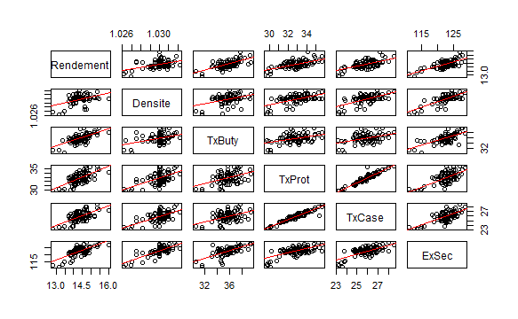

```r
scatterplot <-pairs(~Rendement + Densite + TxButy + TxProt + TxCase + ExSec, data = lait, panel = function(x,y){
  points(x,y)
  abline(lm(y~x), col="red")
})
```

La matrice de dispersion, ou scatterplot matrix en anglais, est une rpztation graphique de la relation entre chaque paire de variables dans une df. En dehors des diags => montrent les graphiques de dispoersion pour chaque variables. Dans un graphe de dispersion, sur l’axe des x => variable explicative l’axe des y => variable à expliquer

Si la relation entre deux variables est linéaires => on peut observer une tendance linéaire => ici, on voit bien que cela confirme notre réponse précédante

Si une majorité des pts se trouvent dans une partie spécifique du graphique => indique une relation non linéaire ou une influence d’une variable non incluse dans le graphique

En gros une matrice de corrélation version nuage de pts

Nous ce qu’on cherche c’est d’observer Rendement en variable à observer => on regarde la 1ère ligne

*NB: on peut rajouter les deux lignes de code suivantes si on veut connaitre la pente dans chaque graphe* *“m <- round(coef(lm(y ~ x)), 2)[2] text(mean(x), max(y), paste(”Pente =“, m), pos = 4)”* *NB: on peut juste faire pairs(lait)*

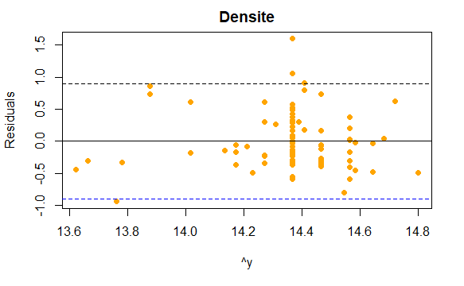

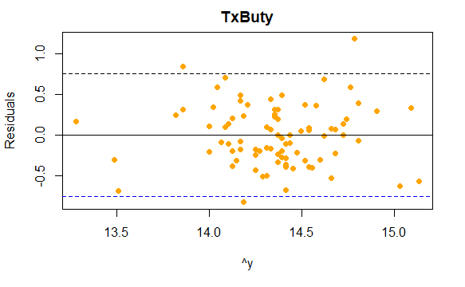

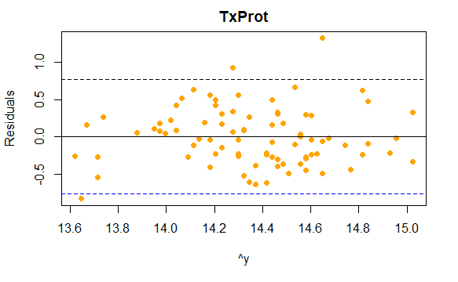

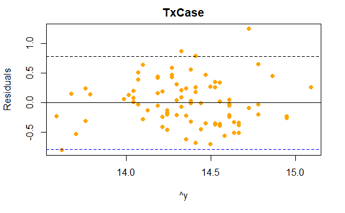

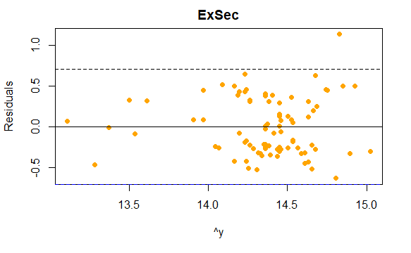

```r
for (i in 1:5){
  model<-lm(Rendement~lait[,i],data=lait)
  resume <- summary(model)

  plot(x = model$fitted.values,y = model$residuals, xlab="^y",ylab="Residuals", pch=19, col="orange",title(main=colnames(lait)[i]))
  abline(h=0)
  abline(h=-2*resume$sigma,lty=2, col = "blue")
  abline(h=2*resume$sigma, lty=2)
}
```

Les données semblent être réparties assez aléatoirement => sauf pour densité et ExSec qui peuvent laisser penser une petite agglutitanation Les données semblent être homosédastiques => variances constantes

**QUESTION 4 - REGRESSION MULTIPLE**

*(a) Estimations des paramètres*

```r
model <- lm(Rendement~Densite + TxCase + TxProt + TxButy + ExSec, data=lait)
resume<-summary(model)
resume
```

```
Call:
lm(formula = Rendement ~ Densite + TxCase + TxProt + TxButy +
    ExSec, data = lait)

Residuals:
     Min       1Q   Median       3Q      Max
-0.47845 -0.23734 -0.03251  0.20549  0.99362

Coefficients:
             Estimate Std. Error t value Pr(>|t|)
(Intercept)  95.74900   50.19040   1.908  0.06006 .
Densite     -94.22167   50.26922  -1.874  0.06458 .
TxCase       -0.04324    0.11835  -0.365  0.71580
TxProt        0.15628    0.08996   1.737  0.08624 .
TxButy        0.08979    0.03100   2.896  0.00488 **
ExSec         0.06879    0.02280   3.017  0.00343 **
---
Signif. codes:  0 ‘***’ 0.001 ‘**’ 0.01 ‘*’ 0.05 ‘.’ 0.1 ‘ ’ 1

Residual standard error: 0.3131 on 79 degrees of freedom
Multiple R-squared:  0.6216,    Adjusted R-squared:  0.5976
F-statistic: 25.95 on 5 and 79 DF,  p-value: 2.103e-15
```

*(b)* On peut voir que seul TxButy et ExSec on une proba critique quasi nul => donc tous les autres termes peuvent être considéré comme nul, ou n’ayant pas de réelle influence sur le rendement (au risque de 5%)

*NB : On peut déduire les résultat précédants : On peut églt le trouver avec l’ANOVA*

*Si l’éleveur réussit à augmenter TxButy et TxProt de 0.005, tout en diminuant TxCase de 0.002 (5pour1000 et 2pour1000)* *=> Quelle qté de fromage en +/- peut-il s’attendre pour 100 litres de lait ?*

Cela va faire augmenter le taux de rendement car ont augmente les variables significativement différentes de 0 et de coeff positif. Le coefficient dans estimate = augmentation du rendement lorsqu’on augment d’une unité la variable (ici de 1 pour 1000).

```r
augmentation <- model$coefficients[5]*5 + model$coefficients[4]*5 - 2*model$coefficients[3]
augmentation
```

```
  TxButy
1.316809
```

*Quel est le pourcentage de la variabilité du rendement expliqué par les variables explicatives ?* *(c) Tracer le graphe des résidus. Commenter.*

```r
#version à la mano
plot(x = model$fitted.values,y = model$residuals, xlab="^y",ylab="Residuals", pch=19, col="red", ylim=c(-1,1))
abline(h=0)
```

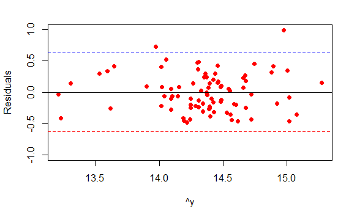

```r
abline(h=-2*resume$sigma,lty=2, col = "red")
abline(h=2*resume$sigma, col="blue", lty=2)
```

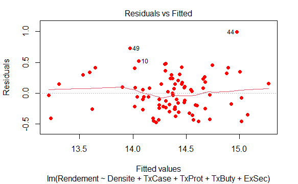

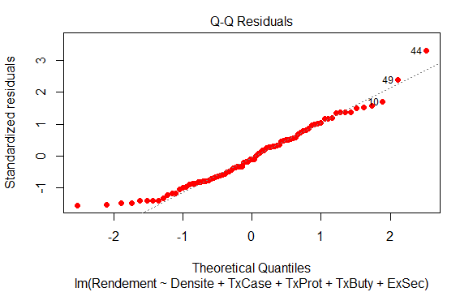

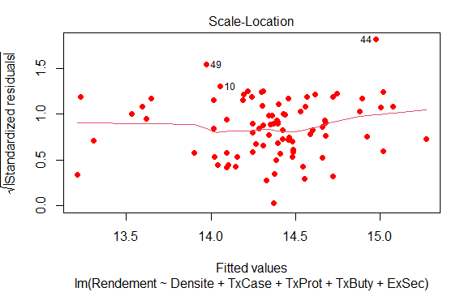

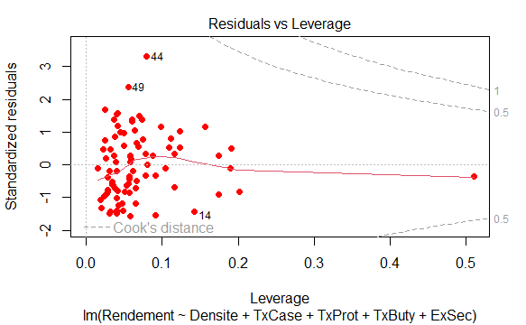

```r
#version automatique
plot(model, pch=19, col="red")
```

Le graphe des résidus semblent avoir une répartition aléatoire et de variance constante. *Lorsqu’on regarde le QQplot => on doit regarder l’alignement des pts sur la droite pour que ça soit normal*

*NB : dans plot(model) on peut rajouter le paramètre which pour choisir quel graphe on veut afficher*

**QUESTION 5 - MODELE 2 - SELECTION AUTO DE VARIABLES AVEC BACKWARD**

```r
mod2 <- step(model, direction = "backward")
```

```
Start:  AIC=-191.61
Rendement ~ Densite + TxCase + TxProt + TxButy + ExSec

          Df Sum of Sq    RSS     AIC
- TxCase   1   0.01309 7.7594 -193.47
<none>                 7.7464 -191.61
- TxProt   1   0.29594 8.0423 -190.43
- Densite  1   0.34448 8.0908 -189.91
- TxButy   1   0.82251 8.5689 -185.03
- ExSec    1   0.89280 8.6392 -184.34

Step:  AIC=-193.47
Rendement ~ Densite + TxProt + TxButy + ExSec

          Df Sum of Sq    RSS     AIC
<none>                 7.7594 -193.47
- Densite  1   0.37278 8.1322 -191.48
- TxButy   1   0.87216 8.6316 -186.41
- ExSec    1   0.88179 8.6412 -186.32
- TxProt   1   1.32491 9.0844 -182.07
```

Pour rappel, l’AIC est un critère d’évaluation de qualité d’un modèle statistique => basé sur le max de vraisemblance du modèle => qui mesure à quel pts les données obs sont probables en supposant le modèle correcte L’AIC ajoute une pénalité au nb de paramètre du modèle pour éviter surapprentissage => permettant de favoriser les modèle + simple

La fonction step : fait tourner un algo qui enlève variable par variable et garde l’AIC le + faible, et s’arrête qd l’AIC ne peut être plus faible que le modèle courant

Le modèle ayant l’AIC la + faible est la préférée.

```r
summary(mod2)
```

```
Call:
lm(formula = Rendement ~ Densite + TxProt + TxButy + ExSec, data = lait)

Residuals:
    Min      1Q  Median      3Q     Max
-0.4786 -0.2345 -0.0338  0.2040  0.9788

Coefficients:
             Estimate Std. Error t value Pr(>|t|)
(Intercept)  98.53667   49.33775   1.997  0.04920 *
Densite     -96.93746   49.44671  -1.960  0.05343 .
TxProt        0.12589    0.03406   3.696  0.00040 ***
TxButy        0.09145    0.03050   2.999  0.00361 **
ExSec         0.06738    0.02235   3.015  0.00344 **
---
Signif. codes:  0 ‘***’ 0.001 ‘**’ 0.01 ‘*’ 0.05 ‘.’ 0.1 ‘ ’ 1

Residual standard error: 0.3114 on 80 degrees of freedom
Multiple R-squared:  0.6209,    Adjusted R-squared:  0.602
F-statistic: 32.76 on 4 and 80 DF,  p-value: 3.647e-16
```

Le modèle retenu est Rendement ~ Densite + TxProt + TxButy + ExSec

**QUESTION 6 - MODELE 3 - SANS INTERCEPT**

```r
mod3 <- lm(Rendement~ -1 + Densite+TxButy+TxProt+ExSec, data=lait)
summary(mod3)
```

```
Call:
lm(formula = Rendement ~ -1 + Densite + TxButy + TxProt + ExSec,
    data = lait)

Residuals:
     Min       1Q   Median       3Q      Max
-0.60302 -0.25235 -0.01667  0.24466  1.07442

Coefficients:
        Estimate Std. Error t value Pr(>|t|)
Densite  1.78140    1.34850   1.321 0.190214
TxButy   0.10454    0.03033   3.447 0.000903 ***
TxProt   0.11633    0.03434   3.388 0.001090 **
ExSec    0.04052    0.01817   2.230 0.028538 *
---
Signif. codes:  0 ‘***’ 0.001 ‘**’ 0.01 ‘*’ 0.05 ‘.’ 0.1 ‘ ’ 1

Residual standard error: 0.3171 on 81 degrees of freedom
Multiple R-squared:  0.9995,    Adjusted R-squared:  0.9995
F-statistic: 4.358e+04 on 4 and 81 DF,  p-value: < 2.2e-16
```

Calcul un modèle de régression linéaire multiple dans lequel le “-1” signifie que l’ordonnées à l’origine ou l’intercept est supprimée du modèle => pour que le modèle ne suppose pas que le rendement est non nul lorsque toutes les autres variables sont nulles

**QUESTION 7 - DETERMINATION DE L’AIC**

```r
extractAIC(model)
```

```
[1]    6.0000 -191.6115
```

```r
extractAIC(mod2)
```

```
[1]    5.0000 -193.4679
```

```r
extractAIC(mod3)
```

```
[1]    4.0000 -191.3322
```

NB : AIC = 2k - 2log(L)

=> avec k le nb de paramètre dans le modèle et L la fonction de vraisemblance maximale du modèle

NB : * extractAIC() retourne un vecteur dont les valeurs sont l’AIC et le nb de paramètres du modèle déjà ajusté * AIC() retourne calcul l’AIC pour un modèle donné

Meilleur modèle en terme d’AIC ? => celui qui a l’AIC la + faible => le modèle n°2 : Rendement ~ Densite + TxProt + TxButy + ExSec

Meilleur modèle en terme de R² ? => + le R² est élevé, + les variables explicatives expliquent la variable à expliquer => on regarde le R² ajusted => sinon on ne peut pas comparer les modèles car nb différents de variable - modèle 1 : 0.59 - modèle 2 : 0.60 - modèle 3 : 0.9995

Quel modèle retenir ? Pourquoi ?

Il y a un choix à faire entre le modèle 2 et le modèle 3. Le modèle numéro 2 à le meilleur AIC, et le modèle 3 à le meilleur R² (et de loin).

Pour une bonne capacité prédictive, il vaut mieux choisir un meilleur R². Le R² est une mesure de la qualité de l’ajustement du modèle qui prend en compte la complexité du modèle.

Pour expliquer le mieux la relation entre les variables indépendantes et la variables dépendantes, il vaut mieux choisir un AIC + faible. L’AIC est une mesure de la qualité de l’ajustement qui prend en compte à la fois la précision et la complexité du modèle. AIC => meilleur compromis entre précision et complexité du modèle.

Etant donné la + gde différence entre les R² et la question suivante, il me semble plus jusdicieux de choisir le modèle 3.

*NB : summary(model)$ajd.r.squared donne le R² ajusted*

**QUESTION 8 - PREDICTION DU RENDEMENT FROMAGER**

- Lait Prim’Holstein

```r
Prim <- predict.lm(mod3, newdata = data.frame(TxButy = 39.7, TxProt = 31.9, Densite = 1.032, ExSec = 130), interval = "prediction")
Prim
```

```
       fit     lwr     upr
1 14.96745 14.2753 15.6596
```

- Lait Normande

```r
Norm <- predict.lm(mod3, newdata = data.frame(TxButy = 42.8, TxProt = 34.5, Densite = 1.032, ExSec = 130), interval = "prediction")
Norm
```

```
       fit      lwr      upr
1 15.59398 14.88333 16.30462
```

CONLUSION :

Une vache Prim’Holstein a un rendement de 14.96 kg/100L de fromage. Une vache Normande a un rendement de 15.59 kg/100L de fromage.

*NB : rbind(data.frame1, data.frame2) pour faire tout en une ligne*